# Apartments

# Plein posted 1 days ago

[LINK](https://www.pararius.com/apartment-for-rent/rotterdam/0363faf4/plein-1953)

Apartment availabile: Immediately

**Details:** 895$, 3 rooms, 55 m²

[figure not shown]

Now available a 3 room apartment located in the Karel de Stoute flat on the 4th floor with south-facing balcony and private storage room in the basement. The apartment has a pleasant and light living experience. You have an unobstructed view of the enclosed garden belonging to the complex. From the complex you can walk straight into the shopping center and to the bus and tram.  
Layout  
Hall, toilet, the kitchen is equipped with various equipment, through the kitchen access to the bathroom with shower and sink. Bedroom on the gallery side, the living room is located at the rear and gives access to the balcony. Also at the rear a bedroom also with access to the balcony.  
Requirements:  
- Acceptance immediately - Maximum rental period of 24 months - Income exclusively from work, the monthly income requirement is 3.5x the rent as gross income - Students allowed if a working family member can provide financial guarantee (above average income required) - The deposit is € 1700.00 - The rental price is excluding gas, water, electricity, TV/internet, etc. - Viewing requests only by email - Heating through block heating, the monthly advance is € 150.00

[interactive chart not shown]

# Beijerlandselaan posted 2 days ago

[LINK](https://www.pararius.com/apartment-for-rent/rotterdam/3f70272b/beijerlandselaan)

Apartment availabile: In consultation

**Details:** 830$, 4 rooms, 90 m²

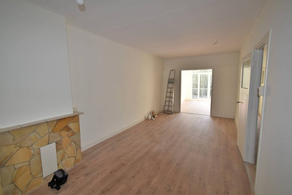

Lovely upholstered apartment for rent in Rotterdam with 1 bedroom in the Hillesluis district.

[interactive chart not shown]

# Libellenstraat posted 0 days ago

[LINK](https://kamernet.nl/en/for-rent/room-rotterdam/libellenstraat/room-2088744)

Room availabile: 01-01-’23

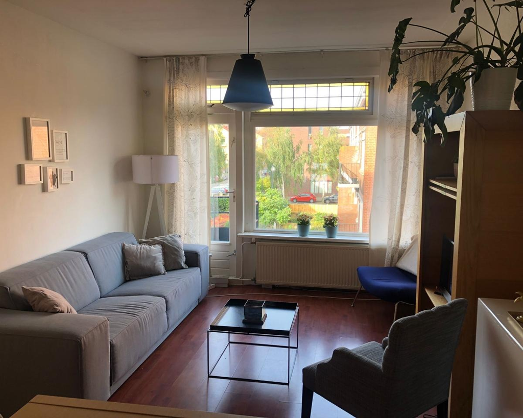

Hallo meiden!Wij zijn op zoek naar een nieuw huisgenootje voor onze prachtige woning in Rotterdam Kralingen. De kamers zijn beschikbaar vanaf 1 januari.De huurprijs is €639 alles inbegrepen voor 2 (kleine) kamers, perfect voor studeren/kleding en slaapkamer. We hebben 2 balkonnetjes (dus altijd zon!). De Lusthofstraat waar de Albert Heijn en verschillende leuke winkels/restaurantjes zijn, zit op steenworp afstand. Metrostation Gerdesiaweg ligt op 5 minuten loopafstand. Het stadscentrum is ongeveer 8 minuten fietsen. Het bureau, bed, kledingkast en gordijnen kunnen in overleg overgenomen worden. Je deelt het huis met 2 meiden van 23 en 26 jaar die beide werkende zijn. We zoeken dan ook het liefst iemand die ook werkende is.Heb je interesse in dit leuke huis en deze fijne kamers, stuur mij of Eline Boele een bericht met een korte omschrijving van jezelf!

# Cleyburchstraat posted 0 days ago

[LINK](https://kamernet.nl/en/for-rent/room-rotterdam/cleyburchstraat/room-2088628)

Room availabile: 25-11-’22 until 02-04-’23

**Details:** 591$ (Utilities excl.), Number of rooms unlisted, 12 m2

[figure not shown]

The room is in a terraced house that is situated at 5 min cycling from the central station, in a lovely, green area. The neighborhood is friendly, quiet en safe. There is a park at 2 min walking and a supermarket and metro station around the corner. The atmosphere is safe and friendly. It is a 10 min cycle to the center of Rotterdam.

# Admiraliteitsstraat posted 0 days ago

[LINK](https://kamernet.nl/en/for-rent/room-rotterdam/admiraliteitsstraat/room-2088483)

Room availabile: 01-01-’23

**Details:** 700$ (Utilities excl.), Number of rooms unlisted, 8 m2

[figure not shown]

- Per 1 januari is er 1 kamer beschikbaar!!- De huurprijs is €700,00 euro excl. gas water licht.- borg €625,00 - je deelt de woonkamer / badkamer en keuken.- locatie Kralingen (aan de Haven)- supermarkt zit op 20 sec afstand.

# Pleinweg posted 1 days ago

[LINK](https://kamernet.nl/en/for-rent/room-rotterdam/pleinweg/room-2088534)

Room availabile: 13-11-’22

**Details:** 625$ (Utilities excl.), Number of rooms unlisted, 19 m2

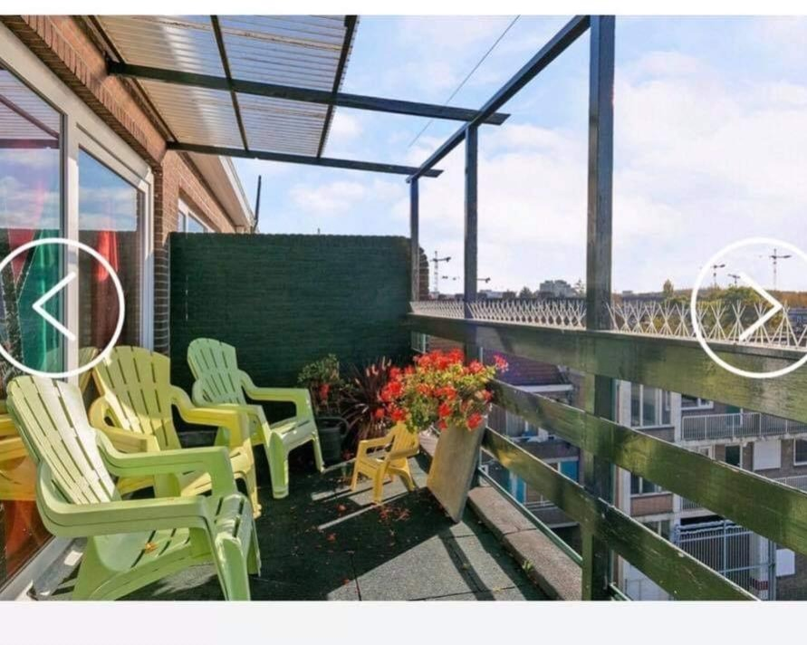

Wil je dichtbij het centrum heerlijk wonen? Dan is dit je kans. Ons huis voor drie personen staat te huur. Ligt heel centraal en binnen 13 min sta je in het centrum van Rotterdam. De woning is op loopafstand van winkelcentra met diverse winkels voor dagelijkse boods., restaurants en ov.Trein is ook heel dicht.Het betreft een netjes huis met drie ruime, fijne kamers te huur . De eerste verdieping is 75 m2 en heeft twee grote slaapkamers (beide 19 m2). Op deze verdieping is er ook een badkamer met douche droger,wasmachine aanwezig en zo ook een toilet, een moderne keuken met alles er op en eraan zoals vaatwasser, koelkast, vriezer, oven, inbouw gasfornuis en een afzuigkap. Er zijn op deze verdieping twee balkons aanwezig. Op de verdieping boven is er ook nog een groot terras aanwezig net als een aparte kamer, met eigen badkamer met toilet, wastafel en bad/douche. Verder aanwezig in de woning: wifi, drie zonnige balkons, cv-combiketel, een nette vloer, dubbelglas, kunststof kozijnen. Alles is netjes en schoon in dit goed onderhouden fijne huis. Één kamer is nog vrij.. We zijn op zoek naar leuke, rustige personen (liefst vrouwen) die sociaal zijn en goed met anderen om kunnen gaan.Er wordt per kamer 625 euro gevraagd. Er wordt een borg van 1,5 maand gevraagd wat je uiteraard terug krijgt na afloop van de huurperiode. Uiteraard gaat alles op basis van een net contract en inschrijving is hier mogelijk. We vragen voor het tekenen van het contract om een copie id en om wat financiële gegevens.. Stuur bij interesse een leuk berichtje met wat informatie over jezelf. Uit ervaring weten we dat er zo’n 500 reacties binnen kunnen komen. Dus dan weet je dat niet iedereen kan komen kijken. Een selectie wordt gemaakt uit de binnen gekomen berichten. Meer informatie volgt na het ontvangen van je bericht Groetjes jasmijn

# Pleinweg posted 1 days ago

[LINK](https://kamernet.nl/en/for-rent/room-rotterdam/pleinweg/room-2088533)

Room availabile: 19-11-’22

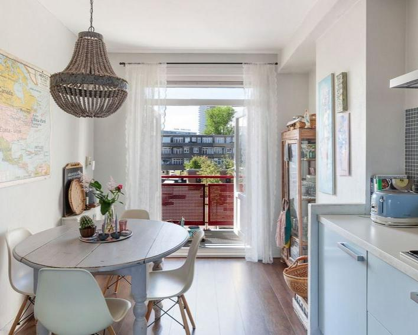

Ben je een leuke, spontane en werkende meid/vrouw? en op zoek naar een fijn plekje in Rotterdam? Dan zoeken wij jou! DIRECT TE HUUR: RUIME LEUKE KAMER (17 pf 25 m2 M2) MET BALKON TE HUUR IN ROTTERDAM TARWEWIJK.., 13 MIN NAAR HET CENTRUM, WONING (105 M2) IS VOORZIEN TWEE ZONNIGE BALKONS, EEN NETTE BADKAMER MET BAD EN DOUCHE, TWEE TOILETTEN, NIEUWE CV-COMBIKETEL, EEN NETTE VLOER, DUBBELGLAS. IN DE KEUKEN (21 M2) IS er een GASFORNUIS, WATERKOKER, twee IJSKASTen , VRIEZER AFZUIGKAP, COMBI-MAGNETRON, VAATWASSER, AIRFRYER. PANNEN BESTEK BORDEN ETC ZIJN OOK AANWEZIG. Ook een WASMACHINE s AANWEZIG. DE WONING IS OP LOOPAFSTAND VAN WINKELCENTRA MET DIVERSE WINKELS VOOR DAGELIJKSE BOODSCHAPPEN, RESTAURANTJES EN OPENBAAR VERVOER. TREINSTATION IS OOK HEEL DICHTBIJ. UITERAARD WORDT ALLES OFFICIEEL GEDAAN MET HUISVESTINGSVERGUNNING, EEN CONTRACT EN INSCHRIJVING. DE HUUR IS 580 EURO PER KAMER met een BORG van 1,5 MAAND. WE VRAGEN VOOR HET TEKENEN VAN HET CONTRACT EEN COPIE ID, WERKGEVERSVERKARING, EEN ARBEIDERSCONTRACT EN OM WAT FINANCIËLE GEGEVENS. NETTE, WERKENDE VROUWELIJKE PERSONEN HEBBEN DE VOORKEUR. I‘M SORRT GUYS😊LAAT EEN LEUK BERICHTJE ACHTER BIJ INTERESSE en wordt vervolgd.

# Beukelsdijk posted 2 days ago

[LINK](https://kamernet.nl/en/for-rent/apartment-rotterdam/beukelsdijk/apartment-2088416)

Apartment availabile: 01-12-’22 until 28-01-’23

**Details:** 800$ (Utilities incl.), Number of rooms unlisted, 35 m2

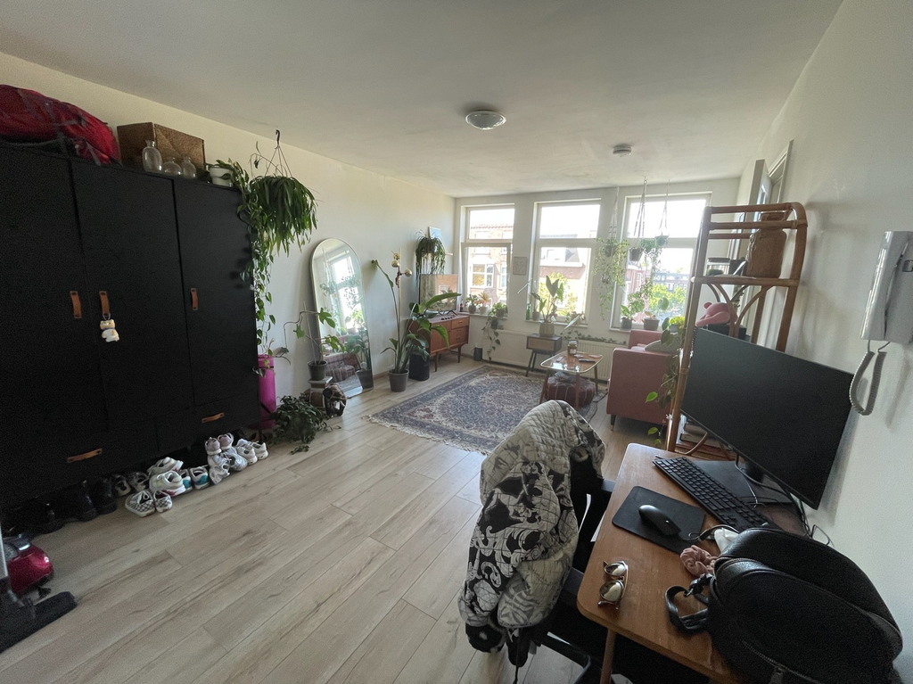

I am travelling abroad and therefore my apartment is for rent for a short period of time. Apartment is available beginning December 2022 until end of Jan 2023 (28-01-2023).You have everything to yourself (kitchen combined with living room, separate bedroom/toilet/bathroom).Costs: €800 all inclusive per month Deposit: 1 x €800I’m looking for a female tennant who is quiet and responsible.

# Socratesstraat posted 2 days ago

[LINK](https://kamernet.nl/en/for-rent/room-rotterdam/socratesstraat/room-2088349)

Room availabile: 18-11-’22

**Details:** 500$ (Utilities excl.), Number of rooms unlisted, 12 m2

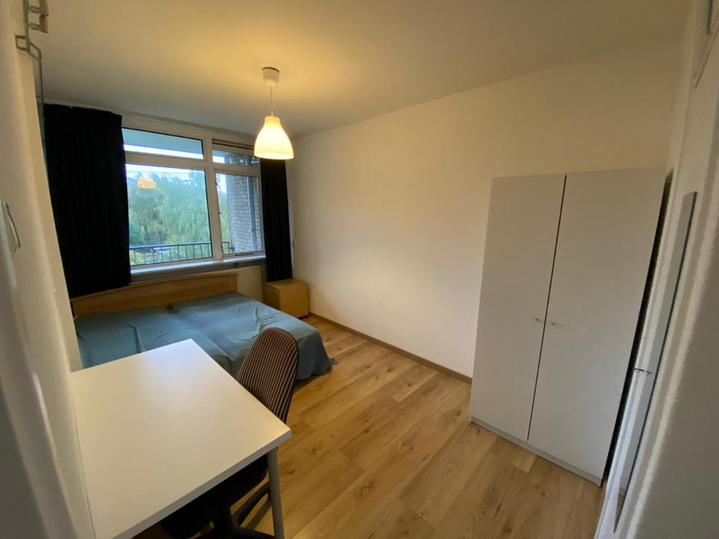

Immediately we have one furnished room (12m2) available in a house on the Socratesstraat in Rotterdam for €500,- per month excl. G/W/E. The facilities such as bathroom, toilet and kitchen will be shared with two roommates.The house is surrounded by amenities such as a tram/bus stop (30 min to Rotterdam Centre) which is 3 minutes walk. It is 6 minutes cycling to the Feyenoord stadium and 5 to 6 minutes drive to both the A15 and A16. You can also bike from this location to the center of Rotterdam, it takes 11 minutes. Furthermore, amenities such as a supermarket and pharmacy within walking distance.Details: - Available immediately; - Bathroom, toilet and kitchen are shared with two other residents.- Rent is excluding gas, water, electricity, internet / TV and local taxes; - Service costs are € 100,- per month for G / W / E; - Furniture costs € 50,- per month; - The room will be furnished, see pictures; - Nearby facilities such as a supermarket, pharmacy and tram / bus stop; - Deposit is equal to two months rent; - Pets are not allowed; - Smoking is not allowed; - Registration with the municipality is possible.Are you interested in this neat furnished room? Please contact us and we will plan a viewing. Leave your email address and phone number in the message.

# Dresselhuysstraat posted 2 days ago

[LINK](https://kamernet.nl/en/for-rent/room-rotterdam/dresselhuysstraat/room-2088291)

Room availabile: 01-12-’22 until 04-02-’23

**Details:** 560$ (Utilities excl.), Number of rooms unlisted, 16 m2

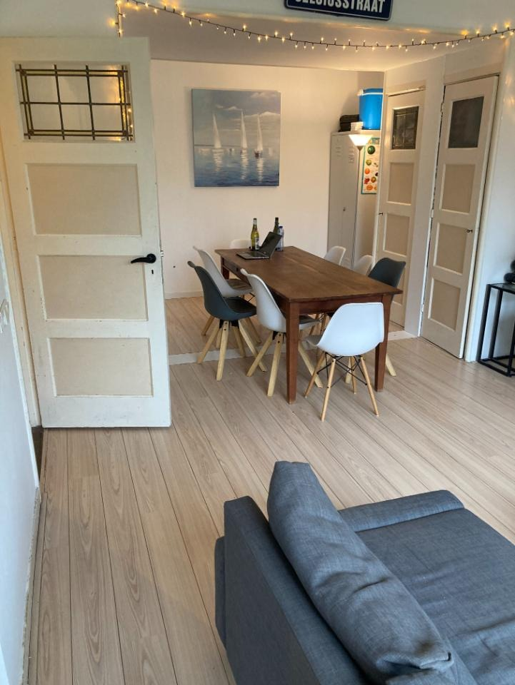

In the month of January I am looking for someone to sublet my room. The specific dates can be flexible, and in consultation, it would also be possible to include the period of December + January. The room is light, pleasant and comes completely furnished. Train (Rotterdam CS) subway and tram are all in walking distance. A common area, kitchen and bathroom is shared with three guys (23-25 years)

# Heemraadsplein posted 2 days ago

[LINK](https://kamernet.nl/en/for-rent/room-rotterdam/heemraadsplein/room-2088283)

Room availabile: 25-11-’22

**Details:** 650$ (Utilities incl.), Number of rooms unlisted, 8 m2

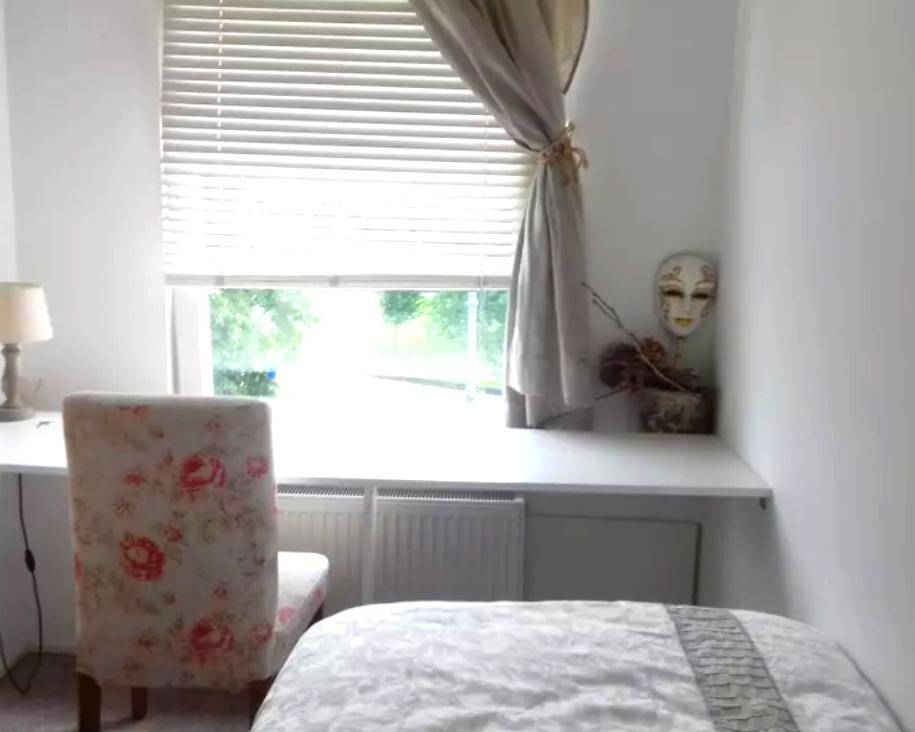

Small But Cozy Private Bedroom in Recently Renovated ApartmentThis very wonderful and spacious apartment offers all of you: students and working professionals, a warm place to stay. This single bedroom is fully furnished and clean. It has a bed, a wardrobe, and a desk. The newly renovated apartment(135m2) consists of bedrooms, a large living area (80 m2), a fully equipped kitchen, and a modern bathroom with spa shower and jacuzzi. All comfort is there to make you feel home.Enjoy Rotterdam!This property is located in Heemraadsplein, very close to the city center and all transport. Also, It is very close to the beautiful Heemraadspark where you can relax and enjoy the fresh air. Supermarkets, bars, restaurants, and landmarks all are nearby for you to enjoy an easy and joyful life. Trams, buses are available too and from there you are well connected to all parts of Rotterdam.

# Oostzeedijk posted 2 days ago

[LINK](https://kamernet.nl/en/for-rent/room-rotterdam/oostzeedijk/room-2088279)

Room availabile: 01-12-’22

**Details:** 495$ (Utilities incl.), Number of rooms unlisted, 18 m2

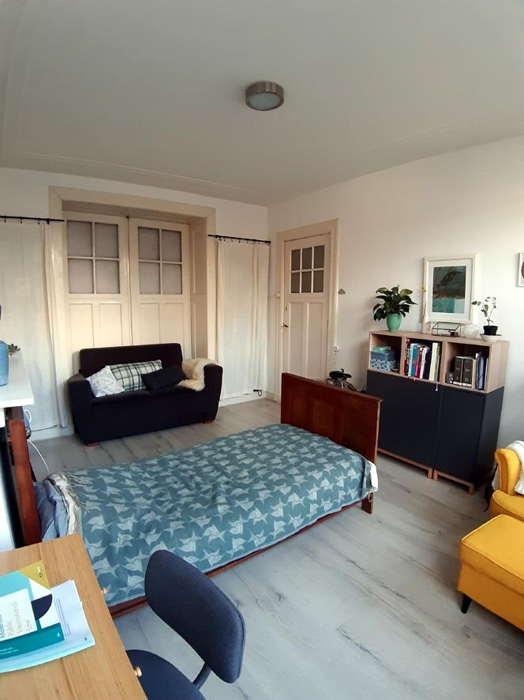

NO INTERNATIONALSToplocatie in Kralingen, op loopafstand van de universiteit. Rustige, ruime kamer, 18m2, hoge plafonds, twee ingebouwde kasten. GEEN studentenhuis, wel 1 andere studente (19, filosofie) in huis. Keuken, badkamer en tuin worden gedeeld met max. 2 personen, toilet met 1 persoon. Incl. WIFI. Ideaal voor zelfstandige studenten die zichzelf bezig kunnen houden en die thuis een rustige plek zoeken. Winkels op 5 minuten lopen (Appie, Aldi, natuurvoeding etc.) en het openbaar vervoer stopt voor de deur. Alleen studenten EUR, en ladies only! (dat betekent Erasmus Universiteit, en alleen meiden)Belangstelling? Stuur een mailtje en vertel wat over jezelf: wat je studeert/gaat studeren, je interesses, wat je van een kamer verwacht en waarom je vindt dat JIJ deze kamer moet krijgen.Zo lang deze advertentie hier staat is de kamer nog niet verhuurd.En ook niet onbelangrijk: je krijgt ALTIJD binnen 24 uur antwoord! :-)

# Middellandplein posted 3 days ago

[LINK](https://kamernet.nl/en/for-rent/studio-rotterdam/middellandplein/studio-2088223)

Studio availabile: 01-01-’23

**Details:** 800$ (Utilities excl.), Total 1 room (1 bedroom), 34 m2

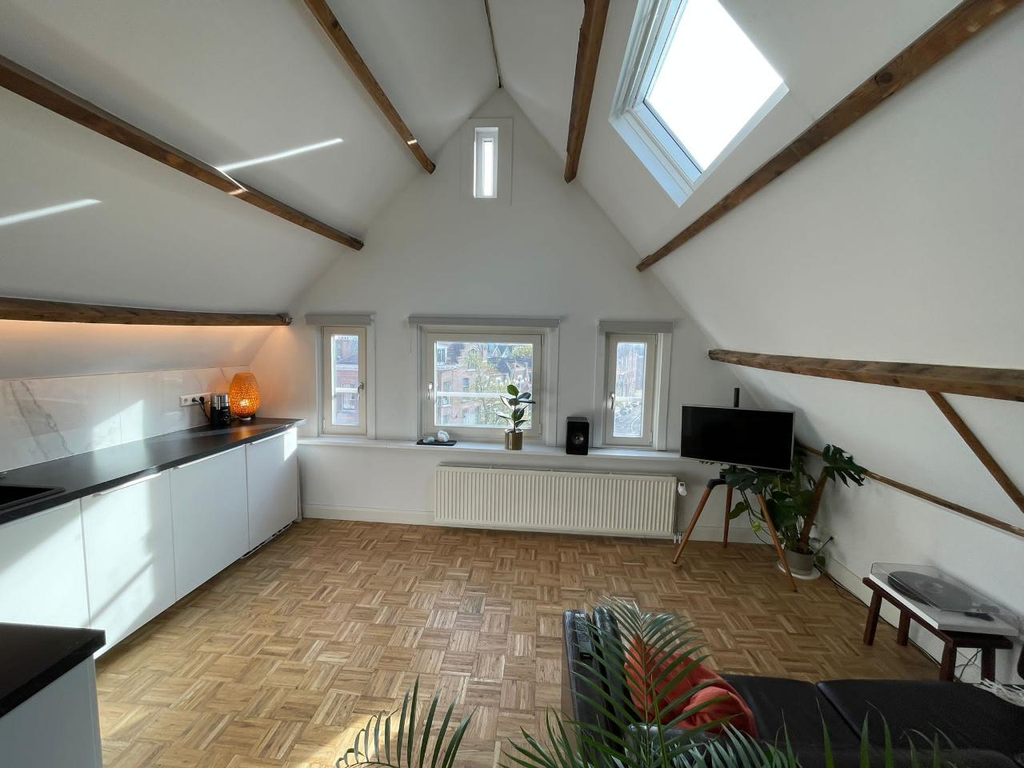

Studio summary:- Fully furnished studio with open kitchen, separate bathroom, entrance hallway and attic- 34m2 on the 4th floor + attic with ladder for storage- Located very central in the popular Middellandplein / West neighborhood- Within walking distance to Central Station (15 min) and beautiful Heemraadsingel canal (3 min)- Next to the tram and bus stop and easy access to main roads- Fully renovated in 2021 (including isolation and new efficient heating system)- High ceilings, wooden floor and beautiful classic elements- South oriented, lots of natural light and calm atmosphere- Stunning views of Rotterdam skyline including famous Euromast- Equipped with new electronics (fridge, dishwasher, oven, microwave, washing and washing machine in bathroom)- High speed glasfiber Internet connectionLocation:Middellandplein is located in a well-known shopping street in Rotterdam. It is a typical Rotterdam street with beautiful 19th-century buildings. The street is full of shops and cozy restaurants. You can walk to the heart of the city and Central Station within a few minutes. Movie houses, restaurants, cafes and museums are all nearby. The tram stop is in front of the door. MC academic hospital and universities are within cycling distance.Requirements:- Rental price € 800 per month- Excl. gas, water and electricity, Internet and services- Available from January 1st 2023 (or sooner on request)2 months deposit- Minimum rental period 12 monthsEmployment contract required (minimum bruto income equals 3x monthly rental price)- Suitable for only 1 person- Internationals and expatriates are welcome!